# COMPSCIX 415.2 Homework 7

Mario Casas Gonzalez

July 24, 2018

```r
library(mdsr)
library(tidyverse)
library (readr)
library(broom)
```

### Exercise 1

#### Load the train.csv dataset into R. How many observations and columns are there?

There is 1,460 observation and 81 variables i.e. columns in the ‘train.csv’ dataset.

```r
train_dataset <- read_csv('C:/Users/mcgonzalez/Documents/Training/Berkeley/COMPSCI X415.2 - 002 Introduction to Data Science/Session 7 Homework/train.csv')
glimpse(train_dataset)
```

```
## Observations: 1,460
## Variables: 81
## $ Id            <int> 1, 2, 3, 4, 5, 6, 7, 8, 9, 10, 11, 12, 13, 14, 1...
## $ MSSubClass    <int> 60, 20, 60, 70, 60, 50, 20, 60, 50, 190, 20, 60,...
## $ MSZoning      <chr> "RL", "RL", "RL", "RL", "RL", "RL", "RL", "RL", ...
## $ LotFrontage   <int> 65, 80, 68, 60, 84, 85, 75, NA, 51, 50, 70, 85, ...
## $ LotArea       <int> 8450, 9600, 11250, 9550, 14260, 14115, 10084, 10...
## $ Street        <chr> "Pave", "Pave", "Pave", "Pave", "Pave", "Pave", ...
## $ Alley         <chr> NA, NA, NA, NA, NA, NA, NA, NA, NA, NA, NA, NA, ...
## $ LotShape      <chr> "Reg", "Reg", "IR1", "IR1", "IR1", "IR1", "Reg",...
## $ LandContour   <chr> "Lvl", "Lvl", "Lvl", "Lvl", "Lvl", "Lvl", "Lvl",...
## $ Utilities     <chr> "AllPub", "AllPub", "AllPub", "AllPub", "AllPub"...
## $ LotConfig     <chr> "Inside", "FR2", "Inside", "Corner", "FR2", "Ins...
## $ LandSlope     <chr> "Gtl", "Gtl", "Gtl", "Gtl", "Gtl", "Gtl", "Gtl",...
## $ Neighborhood  <chr> "CollgCr", "Veenker", "CollgCr", "Crawfor", "NoR...
```

[output cut: 68 more lines]

### Exercise 2

#### • Visualize the distribution of SalePrice.

#### • Visualize the covariation between SalePrice and Neighborhood.

#### • Visualize the covariation between SalePrice and OverallQual.

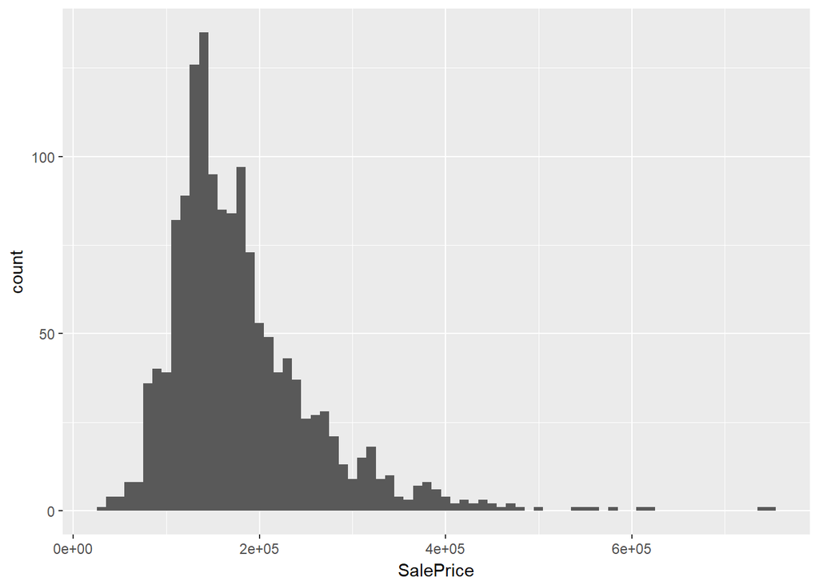

```r
train_dataset %>% ggplot(aes(x=SalePrice))+geom_histogram(binwidth = 10000)
```

```r
traindataset_Neighborhood_lm <- lm(SalePrice ~ Neighborhood, data = train_dataset)
tidy(traindataset_Neighborhood_lm)
```

```
## # A tibble: 25 x 5
##    term                estimate std.error statistic  p.value
##    <chr>                  <dbl>     <dbl>     <dbl>    <dbl>
##  1 (Intercept)          194871.    13097.    14.9   1.12e-46
##  2 NeighborhoodBlueste  -57371.    40367.    -1.42  1.55e- 1
##  3 NeighborhoodBrDale   -90377.    18809.    -4.81  1.71e- 6
##  4 NeighborhoodBrkSide  -70037.    14893.    -4.70  2.81e- 6
##  5 NeighborhoodClearCr   17695.    16603.     1.07  2.87e- 1
##  6 NeighborhoodCollgCr    3095.    13819.     0.224 8.23e- 1
##  7 NeighborhoodCrawfor   15754.    15123.     1.04  2.98e- 1
##  8 NeighborhoodEdwards  -66651.    14166.    -4.70  2.78e- 6
##  9 NeighborhoodGilbert   -2016.    14437.    -0.140 8.89e- 1
## 10 NeighborhoodIDOTRR   -94747.    15822.    -5.99  2.67e- 9
## # ... with 15 more rows
```

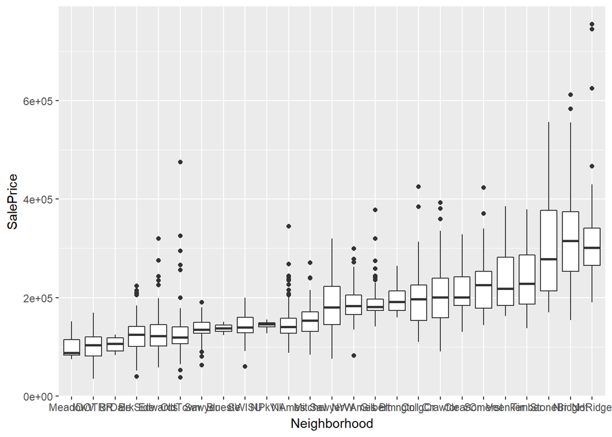

```r
train_dataset %>% ggplot () + geom_boxplot(aes(x=reorder(Neighborhood,SalePrice),y=SalePrice)) + xlab('Neighborhood')
```

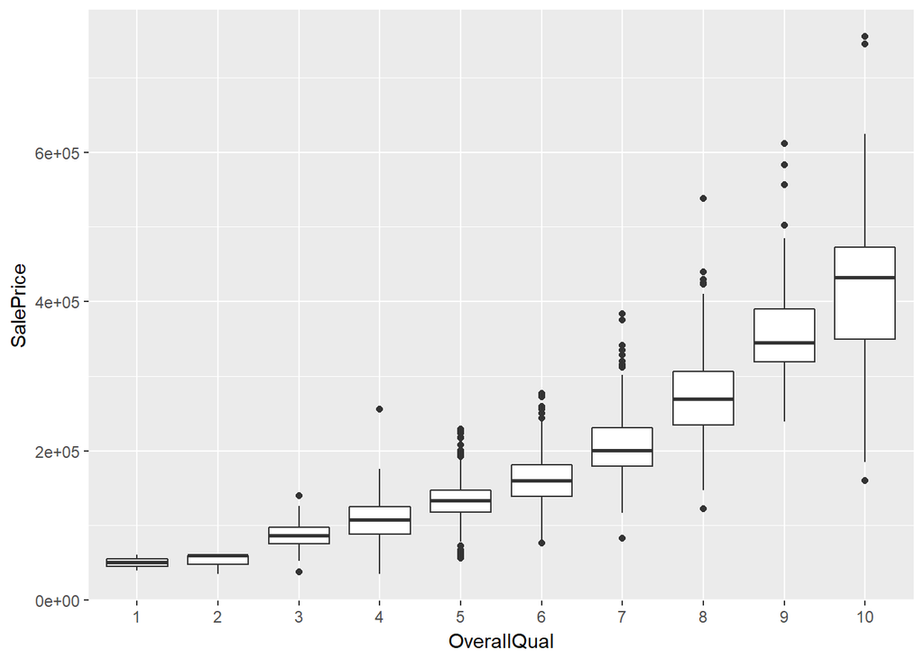

```r
train_dataset %>% ggplot () + geom_boxplot(aes(x=reorder(OverallQual,SalePrice),y=SalePrice)) + xlab('OverallQual')
```

### Exercise 3

##### • take a look at the coefficient,

##### • compare the coefficient to the average value of SalePrice, and

##### • take a look at the R-squared.

The coefficient for Sale Price versus Overall Quality are Intercept -96206, and 45,436.

The average of Sale Price is 180,921.

R squared is 0.626.

```r
lm(formula=SalePrice ~ OverallQual, data = train_dataset)
```

```
##
## Call:
## lm(formula = SalePrice ~ OverallQual, data = train_dataset)
##
## Coefficients:
## (Intercept)  OverallQual
##      -96206        45436
```

```r
SalePrice <- train_dataset$SalePrice
mean(SalePrice)
```

```
## [1] 180921.2
```

```r
glance(lm(formula=SalePrice ~ OverallQual, data = train_dataset))
```

```
## # A tibble: 1 x 11
##   r.squared adj.r.squared  sigma statistic   p.value    df  logLik    AIC
## *     <dbl>         <dbl>  <dbl>     <dbl>     <dbl> <int>   <dbl>  <dbl>
## 1     0.626         0.625 48623.     2437. 2.19e-313     2 -17827. 35659.
## # ... with 3 more variables: BIC <dbl>, deviance <dbl>, df.residual <int>
```

### Exercise 4

• What kind of relationship will these features have with our target?

-‘GrLivArea’ shows living area square feet so should have a positive correlation with the Sale Price. Same thing should happen with ‘OverallQual’ as this variable is an indication of the overall material and finish quality.

• Can the relationship be estimated linearly?

They should be.

• Are these good features, given the problem we are trying to solve?

I would say the living space size and overall quality should be helpful in predicting the Sale Price. The p value shown below is low.

```r
lm(formula=SalePrice ~ GrLivArea + OverallQual + Neighborhood, data=train_dataset) %>% tidy()
```

```
## # A tibble: 27 x 5
##    term                estimate std.error statistic  p.value
##    <chr>                  <dbl>     <dbl>     <dbl>    <dbl>
##  1 (Intercept)         -34829.   11541.       -3.02 2.59e- 3
##  2 GrLivArea               55.6      2.50     22.2  2.38e-94
##  3 OverallQual          20951.    1162.       18.0  1.24e-65
##  4 NeighborhoodBlueste -30753.   27697.       -1.11 2.67e- 1
##  5 NeighborhoodBrDale  -43359.   12979.       -3.34 8.57e- 4
##  6 NeighborhoodBrkSide -13025.   10450.       -1.25 2.13e- 1
##  7 NeighborhoodClearCr  24576.   11570.        2.12 3.38e- 2
##  8 NeighborhoodCollgCr  11414.    9497.        1.20 2.30e- 1
##  9 NeighborhoodCrawfor  14444.   10502.        1.38 1.69e- 1
## 10 NeighborhoodEdwards -17843.    9986.       -1.79 7.42e- 2
## # ... with 17 more rows
```

```r
lm(formula=SalePrice ~ GrLivArea + OverallQual + Neighborhood, data=train_dataset) %>% glance()
```

```
## # A tibble: 1 x 11
##   r.squared adj.r.squared  sigma statistic p.value    df  logLik    AIC
## *     <dbl>         <dbl>  <dbl>     <dbl>   <dbl> <int>   <dbl>  <dbl>
## 1     0.787         0.783 37009.      203.       0    27 -17416. 34887.
## # ... with 3 more variables: BIC <dbl>, deviance <dbl>, df.residual <int>
```

• How would you interpret the coefficients on GrLivArea and OverallQual?

They mean for every relative unit we increase the living space or the Overall Quality, the price of the house would increase by 55.56 and 20,951 respectively.

• How would you interpret the coefficient on NeighborhoodBrkSide?

• Are the features significant? • Are the features practically significant?

These features seem to have a practical correlation with the Sale Price, and this is also proved by the low P. value.

• Is the model a good fit?

As indicated by R squared adjusted of 0.783, Yes.

### Exercise 6

```r
sim1a <- tibble(x = rep(1:10, each = 3), y = x * 1.5 + 6 + rt(length(x), df = 2))
sim1a_lm <- lm(formula= y ~ x, data=sim1a)
lm_x <- lm(formula= y ~ x, data=sim1a)
glance(lm_x)
```

```
## # A tibble: 1 x 11
##   r.squared adj.r.squared sigma statistic  p.value    df logLik   AIC
## *     <dbl>         <dbl> <dbl>     <dbl>    <dbl> <int>  <dbl> <dbl>
## 1     0.778         0.770  2.50      97.9 1.22e-10     2  -69.0  144.
## # ... with 3 more variables: BIC <dbl>, deviance <dbl>, df.residual <int>
```

What do you notice about the model’s coefficient on x and the R-squared values?